# HW02

# Exercise 1

## 1.1

Filtering three countries in the 1970’s

```r
gapminder%>%
  filter(year>=1970& year<1980)%>%
  filter(country=='India'|country=='Mexico'|country=='Canada') %>%
  kable()
```

| country | continent | year | lifeExp | pop | gdpPercap |
| --- | --- | --- | --- | --- | --- |
| Canada | Americas | 1972 | 72.880 | 22284500 | 18970.5709 |
| Canada | Americas | 1977 | 74.210 | 23796400 | 22090.8831 |
| India | Asia | 1972 | 50.651 | 567000000 | 724.0325 |
| India | Asia | 1977 | 54.208 | 634000000 | 813.3373 |
| Mexico | Americas | 1972 | 62.361 | 55984294 | 6809.4067 |
| Mexico | Americas | 1977 | 65.032 | 63759976 | 7674.9291 |

## 1.2

Selecting Country and GDPperCap

```r
gapminder %>%
  filter(year>=1970& year<1980)%>%
  filter(country=='India'|country=='Mexico'|country=='Canada') %>%
    select(country, gdpPercap) %>%
  kable()
```

| country | gdpPercap |
| --- | --- |
| Canada | 18970.5709 |
| Canada | 22090.8831 |
| India | 724.0325 |
| India | 813.3373 |
| Mexico | 6809.4067 |
| Mexico | 7674.9291 |

## 1.3

```r
gapminder %>%
  arrange(year) %>%
  group_by(country) %>%
  mutate(IncLifeExp= lifeExp-lag(lifeExp,1)) %>%
  filter(IncLifeExp>0) %>%
  datatable()
```

|  | country | continent | year | lifeExp | pop | gdpPercap | IncLifeExp |
| --- | --- | --- | --- | --- | --- | --- | --- |
| 1 | Afghanistan | Asia | 1957 | 30.332 | 9240934 | 820.8530296 | 1.531 |
| 2 | Albania | Europe | 1957 | 59.28 | 1476505 | 1942.284244 | 4.05 |
| 3 | Algeria | Africa | 1957 | 45.685 | 10270856 | 3013.976023 | 2.608 |
| 4 | Angola | Africa | 1957 | 31.999 | 4561361 | 3827.940465 | 1.984 |
| 5 | Argentina | Americas | 1957 | 64.399 | 19610538 | 6856.856212 | 1.914 |
| 6 | Australia | Oceania | 1957 | 70.33 | 9712569 | 10949.64959 | 1.20999999999999 |
| 7 | Austria | Europe | 1957 | 67.48 | 6965860 | 8842.59803 | 0.680000000000007 |
| 8 | Bahrain | Asia | 1957 | 53.832 | 138655 | 11635.79945 | 2.893 |
| 9 | Bangladesh | Asia | 1957 | 39.348 | 51365468 | 661.6374577 | 1.864 |
| 10 | Belgium | Europe | 1957 | 69.24 | 8989111 | 9714.960623 | 1.23999999999999 |

[output cut: 1449 more lines]

```r
 # filter(IncLifeExp!=min(year))
```

## 1.4

Maximum GDP per capita of each country

```r
gapminder %>%
  group_by(country) %>%
  filter(gdpPercap==max(gdpPercap)) %>%
  datatable()
```

|  | country | continent | year | lifeExp | pop | gdpPercap |
| --- | --- | --- | --- | --- | --- | --- |
| 1 | Afghanistan | Asia | 1982 | 39.854 | 12881816 | 978.0114388 |
| 2 | Albania | Europe | 2007 | 76.423 | 3600523 | 5937.029526 |
| 3 | Algeria | Africa | 2007 | 72.301 | 33333216 | 6223.367465 |
| 4 | Angola | Africa | 1967 | 35.985 | 5247469 | 5522.776375 |
| 5 | Argentina | Americas | 2007 | 75.32 | 40301927 | 12779.37964 |
| 6 | Australia | Oceania | 2007 | 81.235 | 20434176 | 34435.36744 |
| 7 | Austria | Europe | 2007 | 79.829 | 8199783 | 36126.4927 |
| 8 | Bahrain | Asia | 2007 | 75.635 | 708573 | 29796.04834 |
| 9 | Bangladesh | Asia | 2007 | 64.062 | 150448339 | 1391.253792 |
| 10 | Belgium | Europe | 2007 | 79.441 | 10392226 | 33692.60508 |

[output cut: 132 more lines]

## 1.5

Plotting Canada’s life expectancy vs GDP per capita

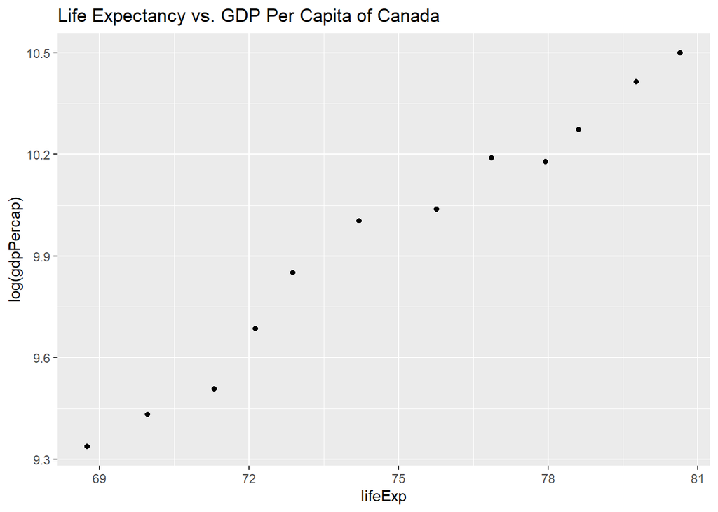

```r
gapmindercan<-gapminder %>%
  filter(country=='Canada')
ggplot(gapmindercan)+
  geom_point(aes(lifeExp,log(gdpPercap)))+
  ggtitle("Life Expectancy vs. GDP Per Capita of Canada")
```

# Exercise 2

## 2.1 Exploring variables using dplyr

The two variables chosen for this exercise are Continent and Life Expectancy Continent being the categorical variable while Life Expectancy the quantitative variable.

### Let’s look at the categorical variable first- Continent.

```r
gapminder %>%
  distinct(continent) %>%
  kable()
```

| continent |
| --- |
| Asia |
| Europe |
| Africa |
| Americas |
| Oceania |

#### Visualizing number of enteries in each continent

```r
gapminder %>%
  group_by(continent) %>%
  count() %>%
  arrange(n) %>%
  kable()
```

| continent | n |
| --- | --- |
| Oceania | 24 |
| Americas | 300 |
| Europe | 360 |
| Asia | 396 |
| Africa | 624 |

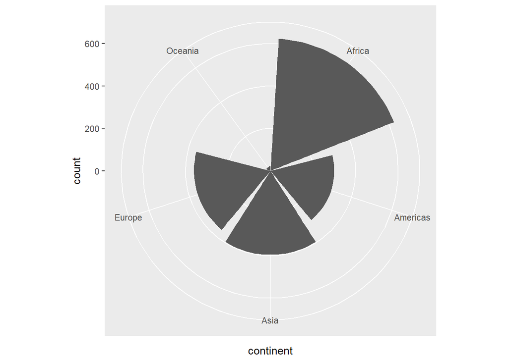

```r
  #table(continent)
  ggplot(gapminder,aes(x=continent))+
  geom_bar(stat = "count")+
  coord_polar()
```

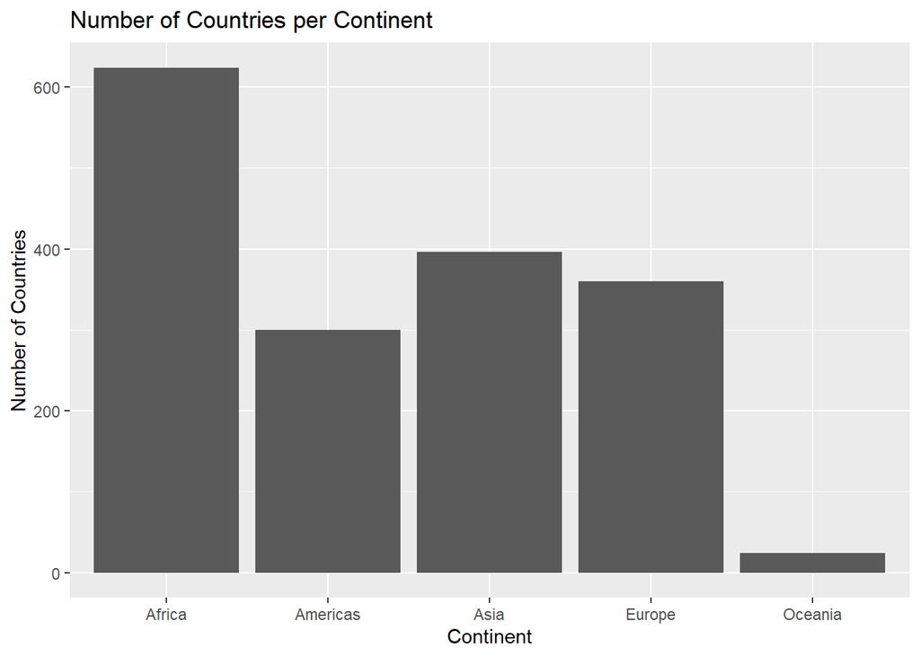

```r
gapminder %>%
  select(country,continent) %>%
  group_by(continent) %>%
  summarize(No_of_Conti = length(continent))%>%
  ggplot(aes(continent,No_of_Conti)) +
  geom_bar(stat='identity') +
  labs(title = "Number of Countries per Continent",
       x = "Continent",
       y = "Number of Countries")
```

### Now lets look at the Life Expectancy (Quantitative) variable

```r
gapminder %>%
  select(lifeExp) %>%
  summary() %>%
  kable()
```

[output not shown]

#### Now let’s look at a graphical representation of the variable to see how the data is distributed. Following is a Life Expectancy histogram:

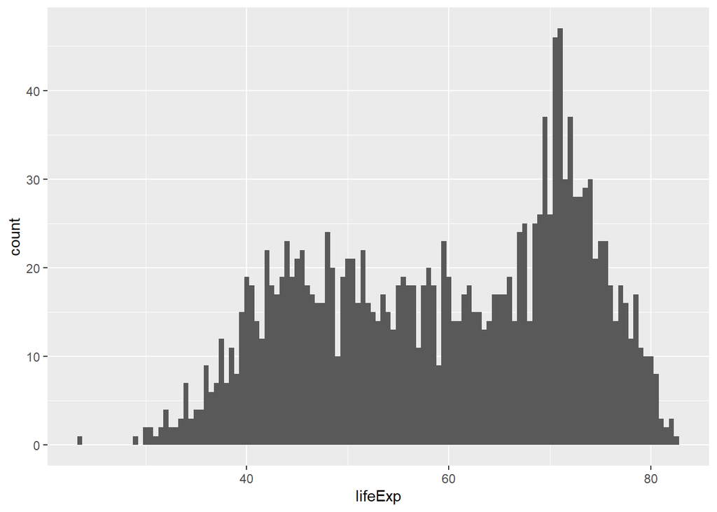

```r
gapminder %>%
  ggplot(aes(lifeExp))+
  geom_histogram(bins = 10, binwidth = 0.5)
```

From the histogram it can be seen that the data is non-symmetrical and is skewed to the left.

#### Now let’s look at the variability of Life Expectancy in different continents by plotting a density plot.

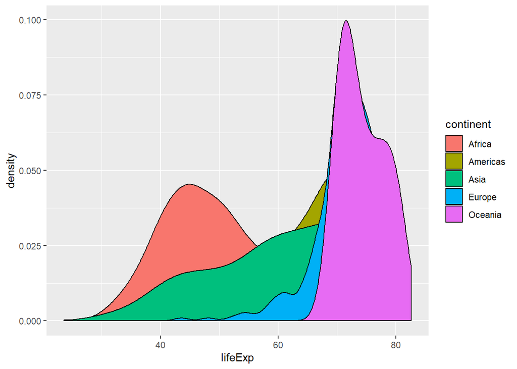

```r
gapminder %>%
  ggplot(aes(lifeExp))+
  geom_density(aes(fill=continent))
```

It can be observed that Oceania, Europe and America have the highest Life Expectancy where as Africa has the least.

# Exercise 3

## Plot 1: Scatter plot for India

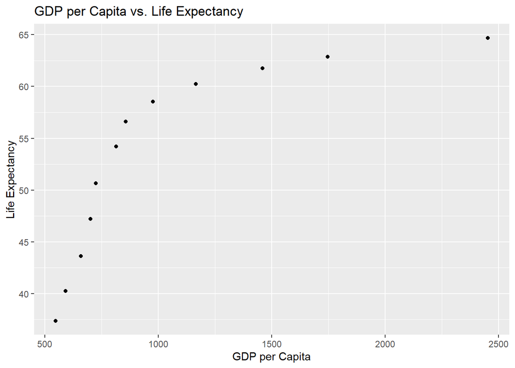

```r
gapminder %>%
  filter(country=="India") %>%
  ggplot()+
  geom_point(aes(gdpPercap,lifeExp))+
  xlab("GDP per Capita")+
  ylab("Life Expectancy")+
  ggtitle("GDP per Capita vs. Life Expectancy")
```

It is evident from the graph that the life expectancy of the population in India increases with the GDP per capita. Two different trends can be seen from the graph. One with high slope that suggestes a substantial increase in life expectancy when GDP increased from 500 to ~1000, followed by a smaller slope that suggests a plateu in the life expectancy.

## Plot 2:

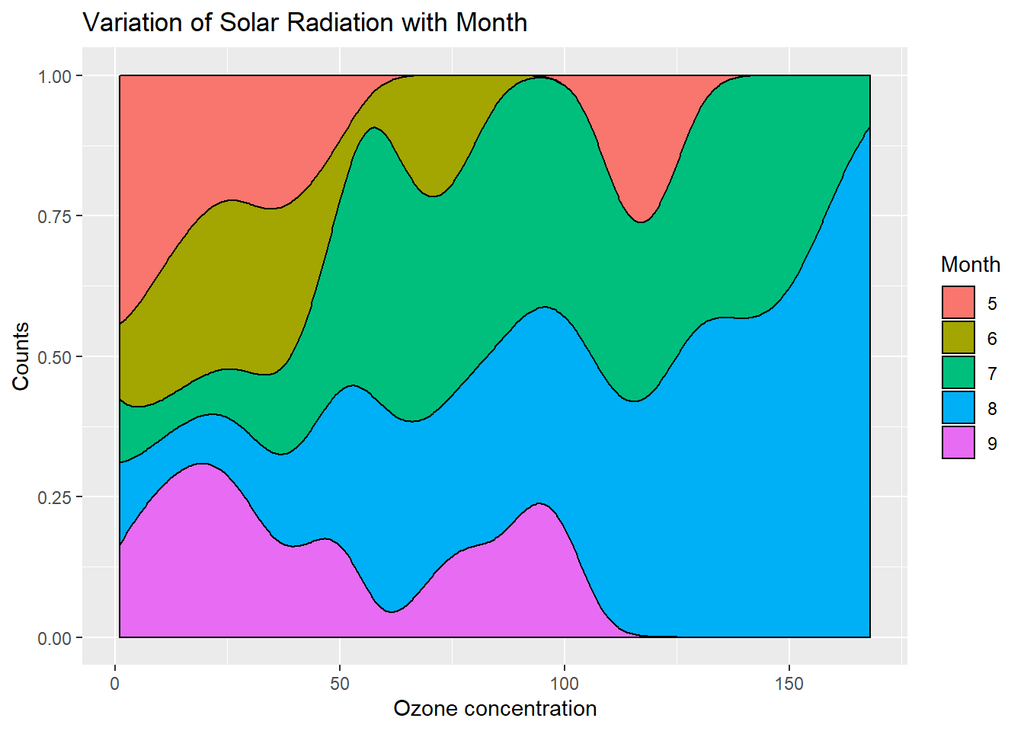

```r
airquality %>%
  ggplot(aes(Ozone))+
  geom_density((aes(fill=factor(Month))),position = 'fill')+
    labs(title="Variation of Solar Radiation with Month",
       x="Ozone concentration",
       y="Counts",
       fill="Month")
```

# Recycling

## 1.

Analyst would not succeed in getting all the data for Afghanistan and Rwanda. The following code run by the analyst produces 12 rows:

```r
filter(gapminder, country == c("Rwanda", "Afghanistan")) %>%
  datatable()
```

|  | country | continent | year | lifeExp | pop | gdpPercap |
| --- | --- | --- | --- | --- | --- | --- |
| 1 | Afghanistan | Asia | 1957 | 30.332 | 9240934 | 820.8530296 |
| 2 | Afghanistan | Asia | 1967 | 34.02 | 11537966 | 836.1971382 |
| 3 | Afghanistan | Asia | 1977 | 38.438 | 14880372 | 786.11336 |
| 4 | Afghanistan | Asia | 1987 | 40.822 | 13867957 | 852.3959448 |
| 5 | Afghanistan | Asia | 1997 | 41.763 | 22227415 | 635.341351 |
| 6 | Afghanistan | Asia | 2007 | 43.828 | 31889923 | 974.5803384 |
| 7 | Rwanda | Africa | 1952 | 40 | 2534927 | 493.3238752 |
| 8 | Rwanda | Africa | 1962 | 43 | 3051242 | 597.4730727 |
| 9 | Rwanda | Africa | 1972 | 44.6 | 3992121 | 590.5806638 |
| 10 | Rwanda | Africa | 1982 | 46.218 | 5507565 | 881.5706467 |

[output cut: 2 more lines]

The correct way to get the results would be by using the or symbol and not a fector. It can be done as follows:

```r
gapminder %>%
  filter(country=="Rwanda"|country=="Afghanistan") %>%
  datatable()
```

|  | country | continent | year | lifeExp | pop | gdpPercap |
| --- | --- | --- | --- | --- | --- | --- |
| 1 | Afghanistan | Asia | 1952 | 28.801 | 8425333 | 779.4453145 |
| 2 | Afghanistan | Asia | 1957 | 30.332 | 9240934 | 820.8530296 |
| 3 | Afghanistan | Asia | 1962 | 31.997 | 10267083 | 853.10071 |
| 4 | Afghanistan | Asia | 1967 | 34.02 | 11537966 | 836.1971382 |
| 5 | Afghanistan | Asia | 1972 | 36.088 | 13079460 | 739.9811058 |
| 6 | Afghanistan | Asia | 1977 | 38.438 | 14880372 | 786.11336 |
| 7 | Afghanistan | Asia | 1982 | 39.854 | 12881816 | 978.0114388 |
| 8 | Afghanistan | Asia | 1987 | 40.822 | 13867957 | 852.3959448 |
| 9 | Afghanistan | Asia | 1992 | 41.674 | 16317921 | 649.3413952 |
| 10 | Afghanistan | Asia | 1997 | 41.763 | 22227415 | 635.341351 |

[output cut: 14 more lines]

## 2. All the tables have been created using datatable() and kable().